# act_report

```python
import pandas as pd
import matplotlib.pyplot as plt
import numpy as np
%matplotlib inline
```

##### Most Popular Breed

```python
df_master = pd.read_csv("twitter_archive_master.csv")
```

```python
df_master.iloc[df_master.fav_count.idxmax], df_master.iloc[df_master.retweet_count.idxmax]
```

```
(tweet_id                                             744234799360020481
 timestamp                                     2016-06-18 18:26:18+00:00
 text                  Here's a doggo realizing you can stand in a po...
 name                                                                NaN
 doggo                                                             doggo
 floofer                                                             NaN
 pupper                                                              NaN
 puppo                                                               NaN
 rating                                                              1.3
 jpg_url               https://pbs.twimg.com/ext_tw_video_thumb/74423...
 predicted_breed                                      labrador retriever
 predict_confidence                                             0.825333
 fav_count                                                        157250
 retweet_count                                                     78323
 Name: 862, dtype: object,
 tweet_id                                             744234799360020481
 timestamp                                     2016-06-18 18:26:18+00:00
 text                  Here's a doggo realizing you can stand in a po...
 name                                                                NaN
 doggo                                                             doggo
 floofer                                                             NaN
 pupper                                                              NaN
 puppo                                                               NaN
 rating                                                              1.3
 jpg_url               https://pbs.twimg.com/ext_tw_video_thumb/74423...
 predicted_breed                                      labrador retriever
 predict_confidence                                             0.825333
 fav_count                                                        157250
 retweet_count                                                     78323
 Name: 862, dtype: object)
```

The breed with the most favourite count and retweet count is labrador retriever and it is the same tweet with 157250 favourite count and 78323 retweet count. The rating for it is 1.3.

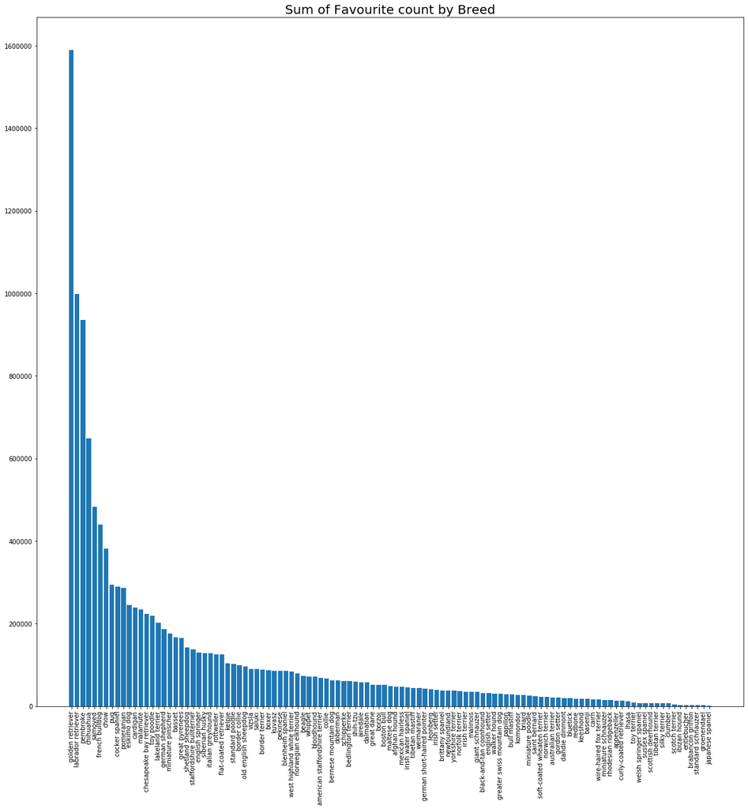

```python
fav_count_by_breed = df_master.groupby("predicted_breed").fav_count.sum().sort_values(ascending=False)
plt.figure(figsize=(20,20))
plt.bar(fav_count_by_breed.index, fav_count_by_breed.values)
plt.xticks(rotation=90)
plt.title("Sum of Favourite count by Breed", fontsize=20)
```

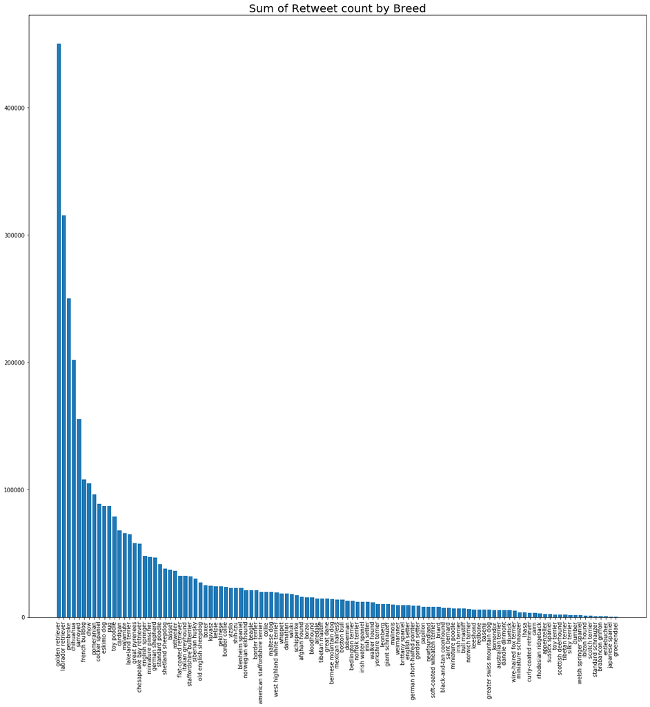

```python
retweet_count_by_breed = df_master.groupby("predicted_breed").retweet_count.sum().sort_values(ascending=False)
plt.figure(figsize=(20,20))
plt.bar(retweet_count_by_breed.index, retweet_count_by_breed.values)
plt.xticks(rotation=90)
plt.title("Sum of Retweet count by Breed", fontsize=20)
```

```python
df_master[['fav_count',"retweet_count"]].corr()
```

|  | fav_count | retweet_count |
| --- | --- | --- |
| fav_count | 1.000000 | 0.927028 |
| retweet_count | 0.927028 | 1.000000 |

Most popular breed in sum of favourite count is golden retriever with almost 1600k favourite counts in total. And it is also the first one in retweet count with around 450k retweet. For the second one is laborador retriever with around 1000k and around 315k retweet count. For the third one is Pembroke with around 935k favourite count and around 250k retweet count. And the correlation between favourite count and retweet count is high (0.927) as we can tell from the bar charts above and by calculation. And we can also observe that most favourite count and retweet count are concentrated at the top few breeds.

##### Rating preference

```python
rating_dist = df_master[~((df_master.rating == np.inf) | (df_master.rating > 4))].rating.value_counts()
```

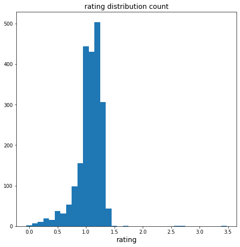

```python
plt.figure(figsize=(8,8))
plt.bar(rating_dist.index, rating_dist.values, width=0.1)
plt.title("rating distribution count", fontsize=14)
plt.xlabel("rating", fontsize=14)
```

Since there are some extreme values. We will remove those to see how people tend to rate (see the above figure). People tend to rate within a normal range but some (not shown in the figure) rate dogs extremely high like like above 10 and even infinity. And you can see that people tend to give high rating (above 1) which rating 1 means the dog gets full score. People are quite generous when rating dogs.

##### Dog type (pupper, puppo, doggo, floofer) distribution

There are 234 pupper, 87 doggo, 25 puppo, 10 floofer in 2175 tweets (note: lots of them without values)

##### Breed Distribution

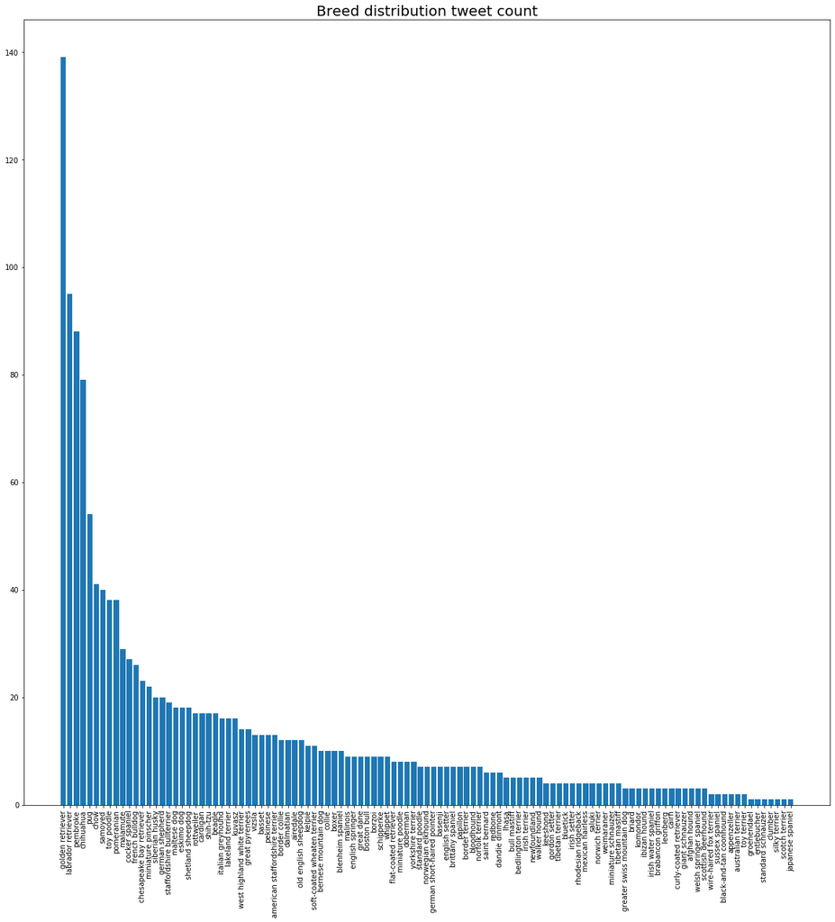

```python
plt.figure(figsize=(20,20))
plt.bar(df_master.predicted_breed.value_counts().index, df_master.predicted_breed.value_counts().values)
plt.xticks(rotation = 90)
plt.title("Breed distribution tweet count", fontsize=20)
```

Top 3 people tweet about are golden retriever, labrador retriever and pembroke. 139 tweets are for Golden Retriever and 95 are for Labrador Retriever and 88 for Pembroke. But the breed of dog is just a prediction which is with potiential error. It means that it may wrongly predict a breed of dog base on the picture.

##### Tweet Behaviour

```python
df_master.timestamp = pd.to_datetime(df_master.timestamp)
tweet_count_by_month = df_master.timestamp.map(lambda x: x.strftime('%m')).value_counts().sort_index()
```

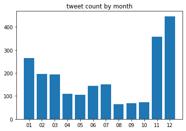

```python
plt.bar(tweet_count_by_month.index, tweet_count_by_month.values)
plt.title("tweet count by month")
```

People tend to tweet in November and December with around 350 and 450 tweets respectively.